# 2020 US Commerce Data

Author

Mohammad Savarmand

Published

December 22, 2023

# Setup

## Load dataset and packages

```r
library(tidyverse)
set.seed(1)
# https://www.kaggle.com/datasets/ammaraahmad/us-ecommerce-record-2020

df <- read_csv(file)
```

## Check to see if an NAs

```r
sum(is.na(df))
```

```
[1] 0
```

## Getting numeric columns for future numerical analysis

```r
df_numeric <- df %>%
  # Select all numeric columns
  select(where(is.numeric)) %>%
  # Excluding Row_ID and Postal Code
  select(-c(1:2))
names(df_numeric)
```

```
[1] "Sales"    "Quantity" "Discount" "Profit"
```

## Removing Outliers (1.5 IQR test)

### Setting conditions

```r
# IQR vector for all columns
IQR_vector <- sapply(df_numeric,IQR)


# Create a list of logicals to index the original datasets
# Index values with "TRUE" will keep their rows
# Index values with "FALSE" will drop their rows
conditions <- lapply(1:ncol(df_numeric), function(col_num) {

  # Setting up the condition values
  IQR_value <- IQR_vector[col_num]
  # Q1 and Q3 for the column being referenced
  Q1_Q3_values <- quantile(df_numeric[[col_num]],probs=c(0.25,0.75))


  # Create a list of conditions for the column being referenced
  return(df_numeric[, col_num] > Q1_Q3_values[1] - 1.5*IQR_value &
         df_numeric[, col_num] < Q1_Q3_values[2] + 1.5*IQR_value)
})
```

### Recursively Intersecting the conditions set

```r
# Recursively interesect the conditions until
# we get one vector of True and Falses to index ROWS ON NOT COLUMNS (*IMPORTANT*)
combined_condition <- Reduce(`&`, conditions)
```

### Filter on conditions and check

```r
# Filter the dataframe on the ROW conditions
df_numeric_filt <- df_numeric[combined_condition, ]
df_filt <- df[combined_condition, ]

# Check the dimensions of the before and after
dim(df_numeric)
```

```
[1] 3312    4
```

```r
dim(df_numeric_filt)
```

```
[1] 2371    4
```

# EDA

## K-Means Cluster Analysis

### Elbow Method

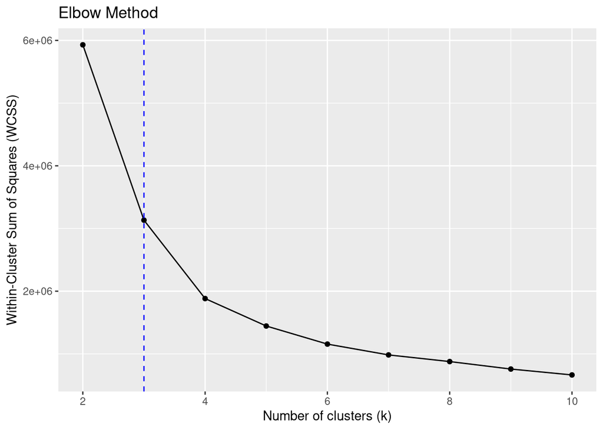

```r
# Perform clustering with different number of clusters (k)
k_values <- 2:10  # Range of k values to try

# Setting up empty vector of zeros
wcss <- numeric(length(k_values))

# Use kmeans and iterate over each k value and calculate WCSS
for (i in seq_along(k_values)) {
  k <- k_values[i]
  kmeans_result <- kmeans(df_numeric_filt, centers = k)

  # The lower the number, the closer the points are to each other
  # As we increase the cluster amount, they will become closer to each other
  # What we are after is the moment where the WCSS drops the greatest
  wcss[i] <- kmeans_result$tot.withinss
}

# Calculate the rate of decrease in WCSS
## Put a zero because diff calculates the difference between the vector
## This means we lose 1 length because the beginning doesn't have a difference
wcss_diff <- c(0, diff(wcss))

# I do this to get rid of negatives. The value with 1 is the max
wcss_diff_pct <- abs(wcss_diff) / max(abs(wcss_diff))

# Find the optimal k based on the the maximum rate of decrease
elbow_index <- which.max(wcss_diff_pct)

# Not 100% if this is correct, but doing it like this makes sense when doing this
# for iris, a dataframe known to have 3 clusters
optimal_k <- k_values[elbow_index]


# Plot the WCSS for different k values
ggplot(data = data.frame(k = k_values, WCSS = wcss), aes(x = k, y = WCSS)) +
  geom_line() +
  geom_point() +
  labs(x = "Number of clusters (k)",
       y = "Within-Cluster Sum of Squares (WCSS)", title = "Elbow Method")+
  geom_vline(xintercept = optimal_k,
             linetype = "dashed",
             color = "blue")
```

### Performing k-means

```r
# kmeans using 3 centers optimal_k
kmeans_basic <- kmeans(df_numeric_filt, centers = optimal_k)

# Overview of the kmeans cluster
# size=length of each cluster
# centers shows the centers for each column and for each k
kmeans_basic_table <- tibble(data.frame(kmeans_basic$size, kmeans_basic$centers))

# Assigning the correct clusters with the correct rows.
# Notice this is the
kmeans_basic_df <- tibble(data.frame(Cluster = as.factor(kmeans_basic$cluster),df_filt))

# Numeric df
kmeans_numeric_basic_df <- tibble(
  data.frame(
    Cluster = as.factor(kmeans_basic$cluster),
    df_numeric_filt))

glimpse(kmeans_numeric_basic_df)
```

```
Rows: 2,371
Columns: 5
$ Cluster  <fct> 3, 3, 2, 3, 3, 2, 3, 3, 3, 3, 3, 1, 3, 3, 3, 3, 3, 1, 1, 3, 3…
$ Sales    <dbl> 48.896, 3.600, 310.744, 12.736, 31.744, 372.144, 16.590, 38.8…
$ Quantity <dbl> 4, 2, 4, 4, 2, 3, 1, 6, 3, 7, 3, 7, 1, 6, 2, 1, 5, 6, 3, 1, 5…
$ Discount <dbl> 0.2, 0.0, 0.3, 0.2, 0.2, 0.2, 0.0, 0.0, 0.0, 0.0, 0.0, 0.0, 0…
$ Profit   <dbl> 8.5568, 1.7280, -26.6352, 2.2288, 3.9680, 27.9108, 5.8065, 18…
```

## Graphing

### Creating ggplot-callable names

Instead of constantly typing the names of the columns manually (which I still do), I decided to figure out how to make ggplot graphs iterable.

```r
all_names <- kmeans_basic_df %>%
  names() %>%
  tibble(ID = 1:length(.),
         Names = .)

all_numeric_names <- kmeans_numeric_basic_df %>%
  names() %>%
  tibble(ID = 1:length(.),
         Names = .)
```

### Graphing with indexing

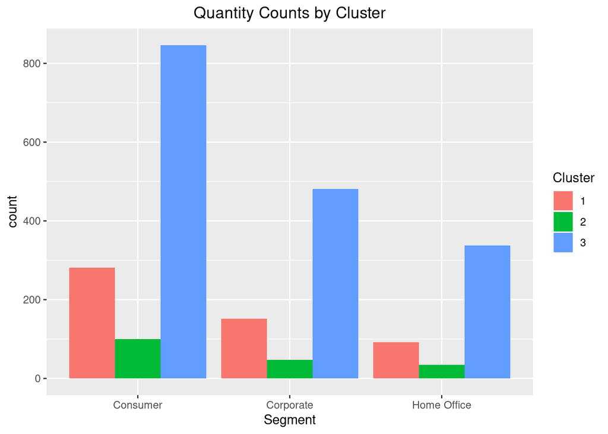

```r
# Convert strings into symbols so ggplot can interpret our stored strings
char_to_sym <- function(string_name){
  string_name %>%
    as.character %>%
    sym
}
# store the column you want for the x variable
x_var <- char_to_sym(all_names[7,2])

# store the column you want for the "fill" aesthetic
fill_var <- char_to_sym(all_names[1,2])

# notice how I wrote !!x_var and !!y_var instead of Segment and Cluster
ggplot(data = kmeans_basic_df, aes(x = !!x_var, fill = !!fill_var)) +
  geom_bar(position = "dodge")+
  ggtitle("Quantity Counts by Cluster") +
  theme(plot.title = element_text(hjust = 0.5))
```

### Pairplot

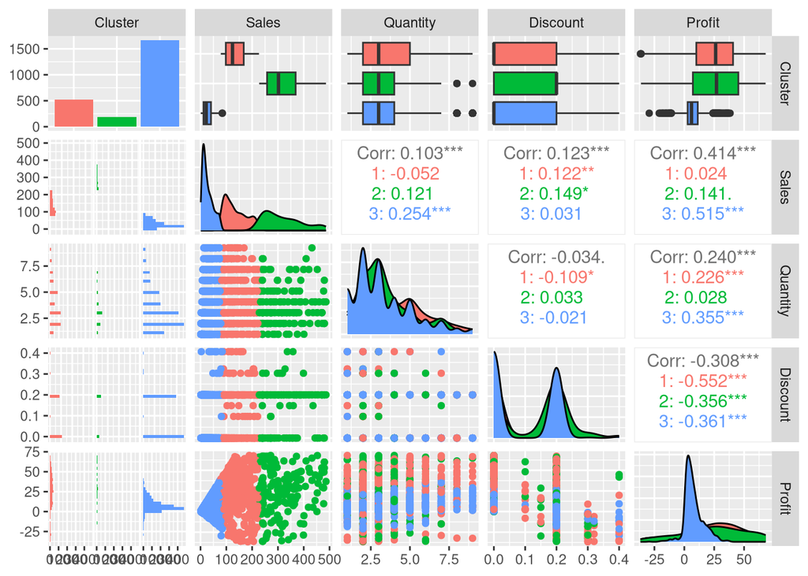

```r
library(GGally)
ggpairs(kmeans_numeric_basic_df,aes(color=Cluster))
```

### Cluster graph using factoextra

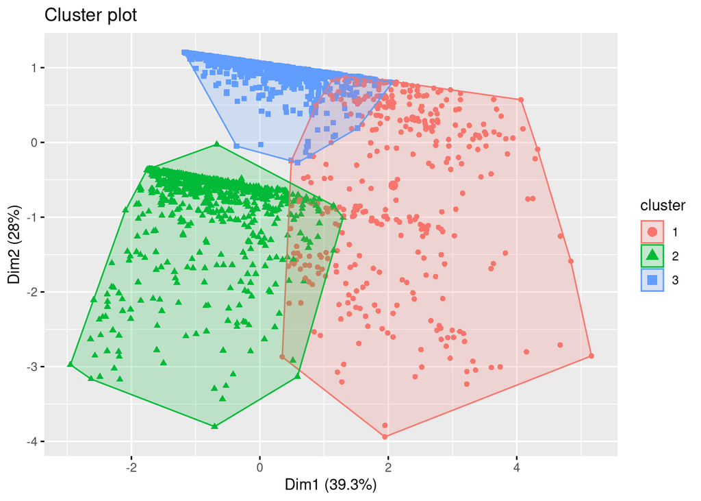

```r
library(factoextra)
# scaling the dataframe helps make a better picture, but scaling on the original dataframe is not always the best solution.
kmeans_scale <- kmeans(scale(df_numeric_filt), centers = optimal_k, nstart = 100)

fviz_cluster(object = kmeans_scale,
             data = scale(df_numeric_filt),
             geom = c("point"),
             ellipse.type = "convex")
```

# Data Analysis

Looking at the pairplot, we can see that the average sales numbers (graph[1,2]) are different between each cluster, but the profits(graph[1,5]) for 2 of the clusters are the same. This may indicate that the profits plateau after a certain sale number, and in fact, they somewhat do when looking at graph[2,5].

## Aggregating the data

### Setting up functions to be iterable (for future use)

```r
# Remind us of this name df
all_names
```

```
# A tibble: 20 × 2
      ID Names
   <int> <chr>
 1     1 Cluster
 2     2 Order.Date
 3     3 Row.ID
 4     4 Order.ID
 5     5 Ship.Mode
 6     6 Customer.ID
 7     7 Segment
 8     8 Country
 9     9 City
10    10 State
11    11 Postal.Code
12    12 Region
13    13 Product.ID
14    14 Category
15    15 Sub.Category
16    16 Product.Name
17    17 Sales
18    18 Quantity
19    19 Discount
20    20 Profit
```

```r
# Convert strings into symbols so ggplot can interpret our stored strings
count_var <- char_to_sym(all_names[7,2])

group_by_var <- char_to_sym(all_names[1,2])

# Grouping the clusters by the segments
df_alter <- kmeans_basic_df %>%
  # notice how I wrote !!group_by_var instead of Cluster
  group_by(!!group_by_var) %>%
  # notice how I wrote !!count_by_var instead of Segment
  count(!!count_var) %>%
  pivot_wider(names_from = !!count_var, values_from = n ) %>%
  # These two bottom lines are dumb but make the code work q-q
  data.frame() %>%
  tibble()
```

## Percentages of Clusters in Segments, vice versa

```r
# Vertical changes. What percent of clusters make up each column?
df_alter %>%
  mutate(across(-!!group_by_var, ~ (. / sum(.)) * 100))
```

```
# A tibble: 3 × 4
  Cluster Consumer Corporate Home.Office
  <fct>      <dbl>     <dbl>       <dbl>
1 1          22.9      22.4        19.8
2 2           8.15      6.91        7.54
3 3          68.9      70.7        72.6
```

```r
# Horizontal changes. What percent of segments make up each cluster?
df_alter %>%
  mutate(across(-!!group_by_var, ~ (. / rowSums(across(-!!group_by_var)))*100 ))
```

```
# A tibble: 3 × 4
  Cluster Consumer Corporate Home.Office
  <fct>      <dbl>     <dbl>       <dbl>
1 1           53.5      29.0        17.5
2 2           54.9      25.8        19.2
3 3           50.8      28.9        20.3
```

## Finding the min/max of Sales and Price in relation to the Clusters

```r
mutate_var1 <- char_to_sym(all_names[17,2])

mutate_var2 <- char_to_sym(all_names[20,2])

sale_profit_summary <- kmeans_basic_df %>%
  group_by(!!group_by_var) %>%
  summarize(
    mutate(
      across(
        c(!!mutate_var1,!!mutate_var2),
        list(max=max,min=min)
      )
    )
  )

sale_profit_summary
```

```
# A tibble: 3 × 5
  Cluster Sales_max Sales_min Profit_max Profit_min
  <fct>       <dbl>     <dbl>      <dbl>      <dbl>
1 1           227.      78.7        68.0      -36.7
2 2           486.     227.         68.0      -36.2
3 3            84.8      0.99       38.3      -29.3
```

# Conclusion

We can only conclude that although Cluster 1 had significantly fewer sales than Cluster 2, they still managed to have the same profit. If we aim for a system where we make the most profit, we must determine how Cluster 1 achieved those profits.

There is currently no single variable or group that differentiates cluster 1 from cluster 2, but if we were to iterate through the “df_alter” object with every single name from the “all_names” object, we might find something after more analysis.